# 06-merge-samples-w-taxonomy

9 February 2022 – THIS HAS BEEN SUPERCEDED BY `13-pcr-replicate-filtering.Rmd`

Merge the ASV sample data frame with the filtered taxonomy data frame from ‘02-taxonomic-filtering.Rmd’

**data filtering question: compare which samples had the lowest read depths across all pcr types (qPCR, metabarcoding) and then assess if there’s a reasonable cut-off (10% of reads from other replicates?)

```r
library(dplyr)
library(tidyr)
library(stringr)
library(ggplot2)
```

## Read in filtered taxonomy data frame

```r
# this version is filtered by Fish Atlas and contains only fishes
taxonomy <- read.csv("csv_outputs/12Sfishatlas.edna.taxonomy.csv") %>%
  select(-X, -class, -phylum, -kingdom, -common, -Sp_ScientificName) %>% # since this was already filtered by class, no reason to retain these other variables (and the common name and sci name from Fish Atlas aren't correct)
  unique() %>%
    filter(taxon != "Perciformes")

taxonomy %>%
  select(qseqid, species, genus, family, order, seq_percID, taxonomic_level, taxon) %>%
  filter(!str_detect(species, "x")) %>%
  # remove hybrids because the mtDNA sequence actually is only one or the other of the parent species
  arrange(qseqid)
```

| qseqid | species | genus | family | order | seq_percID | taxonomic_level | taxon |
| --- | --- | --- | --- | --- | --- | --- | --- |
| Seq1 | Oncorhynchus_clarkii | Oncorhynchus | Salmonidae | Salmoniformes | 100.000 | genus | Oncorhynchus |
| Seq1 | Oncorhynchus_gilae | Oncorhynchus | Salmonidae | Salmoniformes | 100.000 | genus | Oncorhynchus |
| Seq1 | Oncorhynchus_keta | Oncorhynchus | Salmonidae | Salmoniformes | 100.000 | genus | Oncorhynchus |
| Seq1 | Oncorhynchus_masou | Oncorhynchus | Salmonidae | Salmoniformes | 100.000 | genus | Oncorhynchus |
| Seq1 | Oncorhynchus_mykiss | Oncorhynchus | Salmonidae | Salmoniformes | 100.000 | genus | Oncorhynchus |
| Seq1 | Oncorhynchus_kisutch | Oncorhynchus | Salmonidae | Salmoniformes | 99.057 | genus | Oncorhynchus |
| Seq1 | Oncorhynchus_gorbuscha | Oncorhynchus | Salmonidae | Salmoniformes | 98.113 | genus | Oncorhynchus |
| Seq1 | Oncorhynchus_nerka | Oncorhynchus | Salmonidae | Salmoniformes | 98.113 | genus | Oncorhynchus |
| Seq1000 | Oncorhynchus_clarkii | Oncorhynchus | Salmonidae | Salmoniformes | 99.057 | genus | Oncorhynchus |
| Seq1000 | Oncorhynchus_gilae | Oncorhynchus | Salmonidae | Salmoniformes | 99.057 | genus | Oncorhynchus |

[output cut: 990 more lines]

```r
NA
```

```r
# turns out Perciformes is so diverse as to be pretty useless for ID
taxonomy %>%
  filter(taxon == "Perciformes") %>%
  filter(qseqid == "Seq1530")
```

| family | qseqid | species | genus | order | seq_percID | id_rank | top_perc | diff | taxonomic_level | taxon |
| --- | --- | --- | --- | --- | --- | --- | --- | --- | --- | --- |

```r
# look at Salmonidae quickly - if it's just Oncorhynchus and Salvelinus, then we might be able to pull out Salvelinus?
taxonomy %>%
  filter(taxon == "Salmonidae") %>%
  filter(qseqid == "Seq1006")
```

| family | qseqid | species | genus | order | seq_percID | id_rank | top_perc | diff | taxonomic_level | taxon |
| --- | --- | --- | --- | --- | --- | --- | --- | --- | --- | --- |
| Salmonidae | Seq1006 | Salmo_salar | Salmo | Salmoniformes | 100.000 | 1 | 100 | 0.000 | family | Salmonidae |
| Salmonidae | Seq1006 | Thymallus_tugarinae | Thymallus | Salmoniformes | 98.113 | 2 | 100 | 1.887 | family | Salmonidae |

```r
# because Thymallus is a freshwater fish, I think we could safely pull out Salmo salar... but why is Atlantic salmon present? Fish food?

# how common is it?
# uncollapsed_poolseq_tax_df %>%
#   filter(ASV == "Seq1006") %>%
#   filter(count >0) %>%
#   left_join(., meta)
# there aren't many samples that contain it, but I'm sure we can confidently know it's from the fish food.

# another example with salmonidae
taxonomy %>%
  filter(str_detect(species, "Salvelinus") | str_detect(species, "Oncorhynchus") & taxon == "Salmonidae") %>%
  arrange(qseqid)
```

| family | qseqid | species | genus | order | seq_percID | id_rank | top_perc | diff | taxonomic_level | taxon |
| --- | --- | --- | --- | --- | --- | --- | --- | --- | --- | --- |
| Salmonidae | Seq1148 | Salvelinus_confluentus | Salvelinus | Salmoniformes | 99.057 | 1 | 99.057 | 0.000 | family | Salmonidae |
| Salmonidae | Seq1148 | Salvelinus_namaycush | Salvelinus | Salmoniformes | 99.057 | 1 | 99.057 | 0.000 | family | Salmonidae |
| Salmonidae | Seq1148 | Salvelinus_albus | Salvelinus | Salmoniformes | 98.113 | 3 | 99.057 | 0.944 | family | Salmonidae |
| Salmonidae | Seq1148 | Salvelinus_alpinus | Salvelinus | Salmoniformes | 98.113 | 3 | 99.057 | 0.944 | family | Salmonidae |
| Salmonidae | Seq1148 | Salvelinus_boganidae | Salvelinus | Salmoniformes | 98.113 | 3 | 99.057 | 0.944 | family | Salmonidae |
| Salmonidae | Seq1148 | Salvelinus_curilus | Salvelinus | Salmoniformes | 98.113 | 3 | 99.057 | 0.944 | family | Salmonidae |
| Salmonidae | Seq1148 | Salvelinus_elgyticus | Salvelinus | Salmoniformes | 98.113 | 3 | 99.057 | 0.944 | family | Salmonidae |
| Salmonidae | Seq1148 | Salvelinus_fontinalis | Salvelinus | Salmoniformes | 98.113 | 3 | 99.057 | 0.944 | family | Salmonidae |
| Salmonidae | Seq1148 | Salvelinus_kuznetzovi | Salvelinus | Salmoniformes | 98.113 | 3 | 99.057 | 0.944 | family | Salmonidae |
| Salmonidae | Seq1148 | Salvelinus_leucomaenis | Salvelinus | Salmoniformes | 98.113 | 3 | 99.057 | 0.944 | family | Salmonidae |

[output cut: 104 more lines]

```r
taxonomy %>%
  filter(qseqid == "Seq657")
```

| family | qseqid | species | genus | order | seq_percID | id_rank | top_perc | diff | taxonomic_level | taxon |
| --- | --- | --- | --- | --- | --- | --- | --- | --- | --- | --- |
| Salmonidae | Seq657 | Salvelinus_confluentus | Salvelinus | Salmoniformes | 100.000 | 1 | 100 | 0.000 | family | Salmonidae |
| Salmonidae | Seq657 | Salvelinus_namaycush | Salvelinus | Salmoniformes | 100.000 | 1 | 100 | 0.000 | family | Salmonidae |
| Salmonidae | Seq657 | Brachymystax_lenok | Brachymystax | Salmoniformes | 99.057 | 3 | 100 | 0.943 | family | Salmonidae |
| Salmonidae | Seq657 | Parahucho_perryi | Parahucho | Salmoniformes | 99.057 | 3 | 100 | 0.943 | family | Salmonidae |
| Salmonidae | Seq657 | Salvelinus_albus | Salvelinus | Salmoniformes | 99.057 | 3 | 100 | 0.943 | family | Salmonidae |
| Salmonidae | Seq657 | Salvelinus_alpinus | Salvelinus | Salmoniformes | 99.057 | 3 | 100 | 0.943 | family | Salmonidae |
| Salmonidae | Seq657 | Salvelinus_boganidae | Salvelinus | Salmoniformes | 99.057 | 3 | 100 | 0.943 | family | Salmonidae |
| Salmonidae | Seq657 | Salvelinus_curilus | Salvelinus | Salmoniformes | 99.057 | 3 | 100 | 0.943 | family | Salmonidae |
| Salmonidae | Seq657 | Salvelinus_elgyticus | Salvelinus | Salmoniformes | 99.057 | 3 | 100 | 0.943 | family | Salmonidae |
| Salmonidae | Seq657 | Salvelinus_fontinalis | Salvelinus | Salmoniformes | 99.057 | 3 | 100 | 0.943 | family | Salmonidae |

[output cut: 13 more lines]

```r
# It doesn't look like there are any examples where if we remove Oncorhynchus, then Salvelinus is the only genus remaining that causes the taxonomic level to bump up to family
```

So get rid of Perciformes and retain Salmonidae in its current state.

## Read in ASV-sample table for Poolseq data

```r
asv_tbl <- read.csv("csv_outputs/12S_poolseq_ASVtable.csv") %>%
  rename(sample.PCR = X) %>%
  separate(sample.PCR, into = c("sample", "rep"), remove = F)
# pivot longer for ease of joining
asv_long_tbl <- asv_tbl %>%
  pivot_longer(cols = 4:7705, names_to = "ASV", values_to = "count") %>%
  filter(count>0)
```

How many reads per sample?

```r
asv_long_tbl %>%
  group_by(sample.PCR) %>%
  summarise(sum(count)) %>%
  arrange(sample.PCR) %>%
  filter(`sum(count)` <100) %>%
  left_join(., asv_long_tbl) %>%
  select(sample) %>%
  left_join(., asv_long_tbl) %>%
  group_by(sample.PCR, sample) %>%
  summarise(sum(count)) %>%
  arrange(sample)
```

| sample.PCR | sample | sum(count) |
| --- | --- | --- |
| e00006-A | e00006 | 135604 |
| e00006-B | e00006 | 245 |
| e00006-C | e00006 | 94633 |
| e00014-A | e00014 | 164486 |
| e00014-B | e00014 | 294 |
| e00014-C | e00014 | 157850 |
| e00024-A | e00024 | 98602 |
| e00024-B | e00024 | 273 |
| e00024-C | e00024 | 73563 |
| e00032-A | e00032 | 71175 |

[output cut: 38 more lines]

What’s weird about these is that it’s just a single replicate that shows up with such low depth.

Maybe there’s a way forward where if a single replicate received less than 10% of the other replicates, it is removed?

Because we have three field samples and three PCR replicates per location/tide, I’m not too concerned that these low read depth PCR reps will change the mean a ton.

```r
# join data frames
uncollapsed_poolseq_tax_df <- asv_long_tbl %>%
  left_join(., taxonomy, by = c("ASV" = "qseqid"))

# collapse these based on the appropriate taxonomic level
collapsed_poolseq_tax_df <- uncollapsed_poolseq_tax_df %>%
  select(sample.PCR, sample, rep, ASV, count, taxon, taxonomic_level) %>% ## I need to go back and fix the missing % for the species-level hits
  unique()
```

Lots of ASVs with no blast hits - how many?

```r
collapsed_poolseq_tax_df %>% filter(is.na(taxon)) %>%
  select(ASV) %>%
  unique()
```

| ASV |
| --- |
| Seq2 |
| Seq6 |
| Seq10 |
| Seq116 |
| Seq234 |
| Seq322 |
| Seq456 |
| Seq481 |
| Seq571 |
| Seq652 |

[output cut: 990 more lines]

That data frame still contains a bunch of NAs that didn’t have blast hits. Let’s go ahead and remove them.

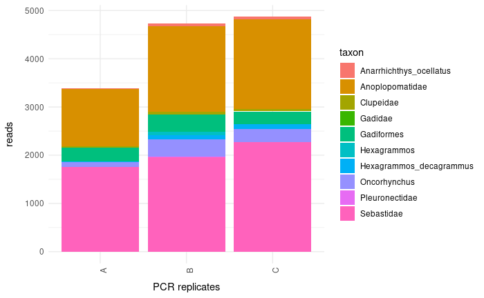

```r
poolseq_tax_tidydf <- collapsed_poolseq_tax_df %>%
  filter(!is.na(taxon)) %>% # remove NAs
  filter(count > 0, taxon != "Actinopteri", taxon != "Eukaryota")  %>% # not informative
  select(-ASV) # remove entries with zero reads for that sequence

# take a quick look at sample composition
poolseq_tax_tidydf %>%
  group_by(sample.PCR) %>%
  filter(sample == "e00001") %>%
  ggplot(aes(x = rep, y = count, fill = taxon)) +
  geom_bar(stat="identity") +
  theme_minimal() +
  theme(
    axis.text.x = element_text(angle = 90),
    axis.title.x = element_text(margin = margin(t=10)),
    axis.title.y = element_text(margin = margin(r=10))
  ) +
  labs(
    y = "reads",
    x = "PCR replicates"
  )
```

```r
NA
NA
```

How many total unique taxa are we even worrying about?

```r
poolseq_tax_tidydf %>%
  select(taxon, taxonomic_level) %>%
  unique() %>%
  arrange(taxon)
```

| taxon | taxonomic_level |
| --- | --- |
| Ammodytidae | family |
| Anarrhichthys_ocellatus | species |
| Anoplopomatidae | family |
| Artedius | genus |
| Artedius_fenestralis | species |
| Atheresthes | genus |
| Aulorhynchus_flavidus | species |
| Clupeidae | family |
| Cottidae | family |
| Gadidae | family |

[output cut: 18 more lines]

```r
NA
```

Here is the decision point - do we group up or group down - e.g., does Artedius_fenestralis become Artedius or vice versa? OR do we assume that there could be both? Some of which are species-level and others that are not?

1. We probably don’t trust the Onchorhynchus tshawytscha - which should probably be kicked up to genus. But do we also want to kick it all the way up to Salmonidae?
2. The only member of the genus Sardinops is Sardinops sagax, which is native to the Indo-Pacific, but NOT Alaska. Go ahead and remove this, since the family, Clupeidae, is already represented.
3. Sardinella, although found in the Pacific, is a tropical/subtropical fish and should be removed.

Current plan: 1. merge Oncorhynchus_tshawytscha reads with Oncorhynchus reads 2. Gadidade into Gadiformes 3. Sebastes into Sebastidae (very few reads for Sebastes - so this will simplify)

not found: sticklebacks? Gasterosteidae?

Group taxonomy for ease of visualizations

```r
edna.dataframe <- poolseq_tax_tidydf %>%
  filter(!taxon %in% c("Sardinella", "Sardinops")) %>%
  # merge chinook into other Onchorhynchus
  mutate(taxon = ifelse(taxon == "Oncorhynchus_tshawytscha", "Oncorhynchus", taxon)) %>%
  mutate(taxon = ifelse(taxon == "Gadidae", "Gadiformes", taxon)) %>%
    mutate(taxonomic_level = ifelse(taxon == "Gadiformes", "order", taxonomic_level)) %>%
  mutate(taxon = ifelse(taxon == "Sebastes", "Sebastidae", taxon)) %>%
    mutate(taxon = ifelse(taxon == "Hexagrammos_decagrammus", "Hexagrammos", taxon)) %>%
      mutate(taxonomic_level = ifelse(taxon == "Hexagrammos", "genus", taxonomic_level)) %>%
      mutate(taxon = ifelse(taxon %in% c("Artedius_fenestralis", "Artedius", "Leptocottus_armatus"), "Cottidae", taxon)) %>%
      mutate(taxon = ifelse(taxon == "Atheresthes", "Pleuronectidae", taxon)) %>%
        mutate(taxon = ifelse(taxon == "Mallotus_villosus", "Osmeriformes", taxon)) %>%
          mutate(taxon = ifelse(taxon == "Aulorhynchus_flavidus", "Gasterosteoidei", taxon)) %>%
            mutate(taxon = ifelse(taxon == "Trichodon_trichodon", "Trichodontidae", taxon)) %>%
              mutate(taxon = ifelse(taxon == "Lipolagus_ochotensis", "Bathylagidae", taxon)) %>%
                mutate(taxon = ifelse(taxon == "Anarrhichthys_ocellatus", "Anarhichadidae", taxon)) %>%
  select(-taxonomic_level) %>%
  # the taxonomic levels aren't accurate, so let's remove those... probably not important from here on out.
  group_by(sample.PCR, taxon) %>%
  mutate(count = sum(count)) %>% # sum reads across taxa
  unique()
```

```r
# how many taxa?
edna.dataframe %>%
  ungroup() %>%
  select(taxon) %>%
  unique() %>%
  arrange(taxon)
```

| taxon |
| --- |
| Ammodytidae |
| Anarhichadidae |
| Anoplopomatidae |
| Bathylagidae |
| Clupeidae |
| Cottidae |
| Gadiformes |
| Gasterosteoidei |
| Hexagrammos |
| Liparis |

[output cut: 7 more lines]

```r
NA
```

```r
# save that
edna.dataframe %>%
  write.csv("csv_outputs/12S_filtered_dataframe.csv")
```

## Add metadata to that data frame

```r
# metadata tidied and ready to go
meta <- read.csv("../metadata/amalga_clean_metadata.csv") %>%
  # fix the 100m samples, which are actually between the pens and the creek
  mutate(distance = ifelse(distance == 100, -100, distance)) %>%
  mutate(dist_grp = distance)

meta
```

| sample | location | label | type | tide | dist_grp | distance |
| --- | --- | --- | --- | --- | --- | --- |
| e00019 | PM | 1120m | eDNA | outgoing | 1120 | 1120 |
| e00020 | PM | 1120m | eDNA | outgoing | 1120 | 1120 |
| e00021 | PM | 1120m | eDNA | outgoing | 1120 | 1120 |
| e00022 | PM | 1200m | eDNA | outgoing | 1200 | 1200 |
| e00023 | PM | 1200m | eDNA | outgoing | 1200 | 1200 |
| e00024 | PM | 1200m | eDNA | outgoing | 1200 | 1200 |
| e00025 | PM | 1280m | eDNA | outgoing | 1280 | 1280 |
| e00026 | PM | 1280m | eDNA | outgoing | 1280 | 1280 |
| e00027 | PM | 1280m | eDNA | outgoing | 1280 | 1280 |
| e00028 | PM | 1360m | eDNA | outgoing | 1360 | 1360 |

[output cut: 162 more lines]

```r
filtered_df_w_metadata <- edna.dataframe %>%
  left_join(., meta) %>%
  filter(!is.na(location))
```

```r
# need to group taxa within the same sample/distance and remove duplicates before plotting
mean.reads.df.to.plot <- filtered_df_w_metadata %>%
  group_by(taxon, tide, distance) %>%
  mutate(mean_reads = mean(count)) %>% # this is the mean number of reads per taxon/tide/distance
  select(taxon, tide, distance, mean_reads) %>% # need to pare down to just this set of variables to avoid counting multiple times
  unique()
```

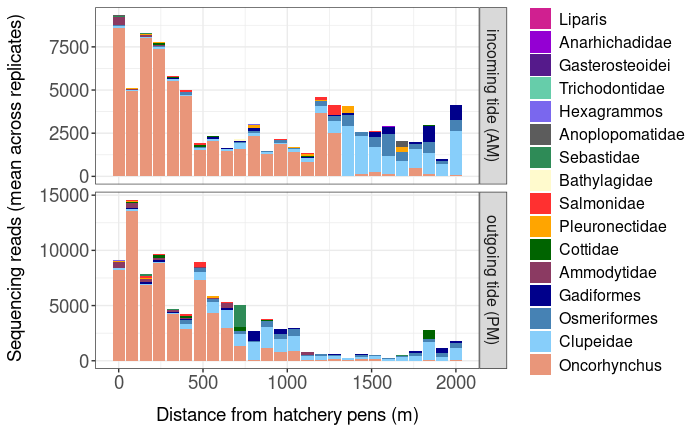

```r
# mean reads per taxon/tide/distance
mean.reads.df.to.plot %>%
  filter(!is.na(tide),
         distance > -10) %>%
  mutate(tide = ifelse(tide == "incoming", "incoming tide (AM)", "outgoing tide (PM)")) %>%
  ggplot(aes(x = distance, y = mean_reads, fill = reorder(taxon, mean_reads))) +
  geom_bar(stat="identity") +
  facet_grid(rows = vars(tide), scales = "free_y") +
  theme_bw() +
   theme(
    axis.text.x = element_text(size = 14),
    axis.text.y = element_text(size = 14),
    axis.title.x = element_text(margin = margin(t=10), size = 14),
    axis.title.y = element_text(margin = margin(r=10), size = 14),
    legend.text = element_text(size = 12),
    legend.title = element_blank(),
    strip.text = element_text(size = 12)
    ) +
  labs(
    y = "Sequencing reads (mean across replicates)",
    x = "Distance from hatchery pens (m)",
    fill = "Taxon") +
  scale_fill_manual(values = c('violetred', "darkviolet", 'purple4','aquamarine3', 'slateblue2', "gray36",'seagreen4', "lemonchiffon", 'firebrick1', "orange1", 'darkgreen', 'hotpink4',"darkblue",'steelblue','lightskyblue', 'darksalmon'))

ggsave("pdf_outputs/12SmeanReadsVdistance.pdf", width = 9, height = 5)
```

I should also create taxonomic groups that are meaningful for the color scheme (e.g., all herrings could be shades of blue…) https://stackoverflow.com/questions/60764545/r-ggplot2-specify-separate-color-gradients-by-group

### Proportion of reads per taxon/sample

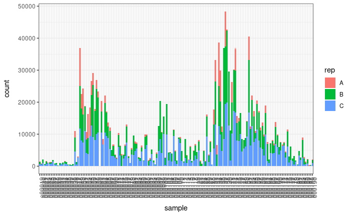

```r
filtered_df_w_metadata %>%
  arrange(sample.PCR) %>%
  filter(!is.na(tide)) %>%
  group_by(sample.PCR) %>% # take the total number of reads summed by PCR replicate first
  mutate(total_reads = sum(count)) %>% # quick plot that
  ggplot(aes(sample, count, fill = rep)) +
  geom_bar(stat="identity", position="stack") +
  theme_bw() +
  theme(
    axis.text.x = element_text(angle = 90),
    axis.title.x = element_text(margin = margin(t=10)),
    axis.title.y = element_text(margin = margin(r=10))
  )
```

Jeez, read depth is all over the place.

Let’s get some summary stats on that:

```r
filtered_df_w_metadata %>%
  arrange(sample.PCR) %>%
  filter(!is.na(tide)) %>%
  group_by(sample.PCR) %>%
  mutate(total_reads = sum(count)) %>%
  ungroup() %>%
  summarise(max(total_reads))
```

| max(total_reads) |
| --- |
| 28449 |

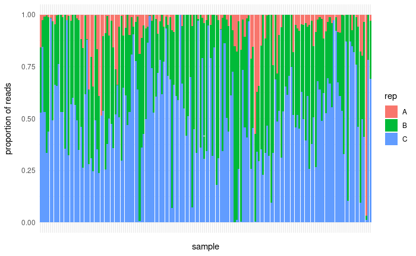

```r
# what about the distribution of reads across replicates for a given sample?
# i.e., the # of reads should be related to the amount of input DNA from the extraction, which suggests replicates should be more similar to each other in read depth
filtered_df_w_metadata %>%
  arrange(sample.PCR) %>%
  filter(!is.na(tide)) %>%
  group_by(sample.PCR) %>%
  mutate(total_reads = sum(count)) %>%
  ungroup() %>%
  group_by(sample) %>%
  mutate(reads = sum(total_reads)) %>%
  group_by(sample, rep) %>%
  mutate(proportion = total_reads/reads) %>%
  ggplot(aes(sample, proportion, fill = rep)) +
  geom_bar(stat="identity", position="stack") +
  theme_minimal() +
  theme(
    axis.text.x = element_blank(),
    axis.title.x = element_text(margin = margin(t=10)),
    axis.title.y = element_text(margin = margin(r=10))
  ) +
  labs(y = "proportion of reads")
```

```r
NA
NA
```

Kind of all over the place.

mean reads = 4409/sample/PCR replicate standard deviation = 4754/sample/PCR rep minimum = 1 read maximum = 28,449 reads

Rather than looking at the PCR replicate and then the field replicates and then the full sample level, I’ll work with the “distance group” which encompasses all replication.

## Make taxon proportions plot

```r
prop.df <- filtered_df_w_metadata %>%
  filter(!is.na(tide),
         type == "eDNA") %>% # remove the controls with no metadata
  select(-location, -label, -dist_grp) %>%
  group_by(distance, tide, taxon) %>% # group by distance
  mutate(tot_tax_reads = sum(count)) %>%
  group_by(distance, tide, taxon) %>%
  mutate(taxon_count = sum(count)) %>%
  select(distance, taxon, tide, tot_tax_reads) %>%
  unique() %>% # if we don't call unique here, it duplicates the summed entries
  group_by(distance, tide) %>%
  mutate(taxon_prop = tot_tax_reads/sum(tot_tax_reads))
```

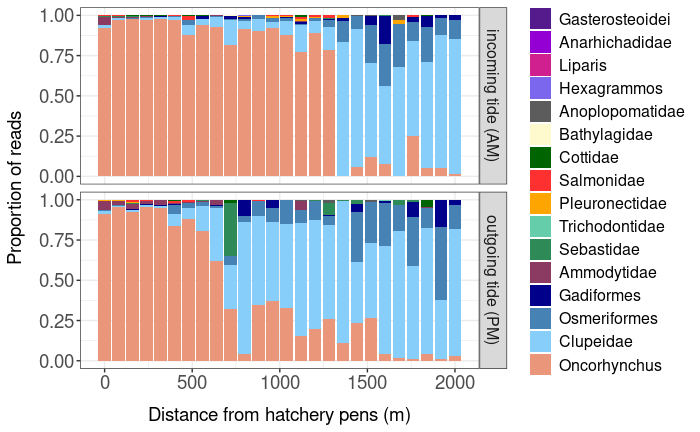

```r
# plot relative proportions of taxa within a tide/distance group
# plot used for PPT
prop.df %>%
    filter(distance > -10) %>%
  mutate(tide = ifelse(tide == "incoming", "incoming tide (AM)", "outgoing tide (PM)")) %>%
  ggplot(aes(distance, taxon_prop, fill = reorder(taxon, taxon_prop)))+
  geom_bar(stat="identity", position="stack") +
  facet_grid(rows = vars(tide)) +
  theme_bw() +
 theme(
    axis.text.x = element_text(size = 14),
    axis.text.y = element_text(size = 14),
    axis.title.x = element_text(margin = margin(t=10), size = 14),
    axis.title.y = element_text(margin = margin(r=10), size = 14),
    legend.text = element_text(size = 12),
    legend.title = element_blank(),
    strip.text = element_text(size = 12)
    ) +
  labs(y = "Proportion of reads",
       x = "Distance from hatchery pens (m)",
       fill = "Taxon") +
  scale_fill_manual(values = c( 'purple4',"darkviolet", 'violetred', 'slateblue2', "gray36", "lemonchiffon",  'darkgreen', 'firebrick1', "orange1",  'aquamarine3',  'seagreen4', 'hotpink4', "darkblue", 'steelblue','lightskyblue', 'darksalmon'))
# the colors match the other two plots, even though the taxon order has changed.

ggsave("pdf_outputs/12S_taxon_proportions_v_distance.pdf", width = 9, height = 5)
```